Tarea 4 - Estadisticas de tendencia Central

Por: Cesar Omar Lopez Arteaga

Febrero 2024

# Pregunta 1

Bajar el archivo Pasteles: trata-se de evaluaciones de pasteles con crema.

Para leer los datos del archivo Pasteles.csv en R, se usara la biblioteca **rio**. Esta biblioteca es útil porque simplifica el proceso de lectura y escritura de datos en diferentes formatos, al proporcionar una función (import()) que automáticamente detecta el formato del archivo y carga los datos de manera adecuada.

Primero, necesitas instalar y cargar la biblioteca rio, lo cual se hace con los siguientess comandos:

```r
# Instalar la biblioteca rio si aún no está instalada
install.packages("rio",repos = "https://cloud.r-project.org/")
```

```r
# Cargar la biblioteca rio
library(rio)
```

Se descargara el archivo Pasteles.csv a una carpeta local, luego se cargara el archivo y se muestrara la estructura de la data, luego se muestra los primeros 15 valores de la tabla

```r
# Leer datos desde un archivo CSV
datos_csv <- import("G:/R IMCA/TAREA 4/DESCARGA_DATA/Pasteles.csv")
```

```r
# Verificar la estructura de los datos
str(datos_csv)
```

```
## 'data.frame':    518 obs. of  11 variables:
##  $ V1                   : int  1 4 5 6 7 8 9 10 11 12 ...
##  $ Ciudad               : int  1 1 1 1 1 2 2 2 1 1 ...
##  $ Condicion_laboral    : int  1 2 2 2 1 2 1 1 1 1 ...
##  $ Clase_edad           : int  2 2 2 3 3 3 3 2 3 3 ...
##  $ Usa_surgelados       : int  2 2 2 2 1 1 2 2 2 2 ...
##  $ Usa_dulces_surgelados: int  2 1 1 1 2 1 1 1 1 2 ...
##  $ Tipo_de_crema        : int  1 1 1 1 1 1 1 1 1 4 ...
##  $ Tipo_de_pastel       : int  2 2 2 2 2 2 2 2 2 2 ...
##  $ Juicio_pastel        : int  4 5 5 6 4 6 6 5 4 5 ...
##  $ Compraria            : int  3 4 5 5 3 4 4 4 4 4 ...
##  $ Juicio_crema         : int  4 5 4 5 4 6 5 5 3 5 ...
```

```r
# Visualizar los primeros registros de los datos
head(datos_csv,n=15)
```

|  | V1 | Ciudad | Condicion_laboral | Clase_edad | Usa_surgelados | Usa_dulces_surgelados | Tipo_de_crema | Tipo_de_pastel | Juicio_pastel | Compraria | Juicio_crema |
| --- | --- | --- | --- | --- | --- | --- | --- | --- | --- | --- | --- |
| 1 | 1 | 1 | 1 | 2 | 2 | 2 | 1 | 2 | 4 | 3 | 4 |
| 2 | 4 | 1 | 2 | 2 | 2 | 1 | 1 | 2 | 5 | 4 | 5 |
| 3 | 5 | 1 | 2 | 2 | 2 | 1 | 1 | 2 | 5 | 5 | 4 |
| 4 | 6 | 1 | 2 | 3 | 2 | 1 | 1 | 2 | 6 | 5 | 5 |
| 5 | 7 | 1 | 1 | 3 | 1 | 2 | 1 | 2 | 4 | 3 | 4 |
| 6 | 8 | 2 | 2 | 3 | 1 | 1 | 1 | 2 | 6 | 4 | 6 |
| 7 | 9 | 2 | 1 | 3 | 2 | 1 | 1 | 2 | 6 | 4 | 5 |
| 8 | 10 | 2 | 1 | 2 | 2 | 1 | 1 | 2 | 5 | 4 | 5 |
| 9 | 11 | 1 | 1 | 3 | 2 | 1 | 1 | 2 | 4 | 4 | 3 |
| 10 | 12 | 1 | 1 | 3 | 2 | 2 | 4 | 2 | 5 | 4 | 5 |

[output cut: 5 more lines]

# Pregunta 2

Calcular distribución, moda, y entropía absoluta, relativa y también los cuantiles (0.01, 0.025, 0.05, 0.25, 0.50, 0.75, 0.95, 0.975, 0.99) de las variables 8, 9, 10, consideradas numéricas, aún sean ordenadas. Calcular como indicado y con la función quantile().

```r
# Instalar el paquete para el calculo de moda
install.packages("DescTools",repos = "https://cloud.r-project.org/")
```

```r
# Cargar el paquete para el calculo de la moda
library(DescTools)
```

```r
# definicion de funcion que calcula los cuartiles
Calc<-function(df,columna){

  nombres<-names(df)
  for(i in 1:length(columna)){
    cat("#######################   Variable",nombres[columna[i]],"  ########################\n")

    # Calculo de la frecuencia de cada variable
    frecuencia<-eval(parse(text = paste0("table(df[,",columna[i],"])")))

    # Calculo de la frecuencia relativa de cada variable
    frecuencia_Relativa<-frecuencia/sum(frecuencia)

    # Calculo de la Entropia
    h = -sum(frecuencia_Relativa*log(frecuencia_Relativa,2))

    # Calculo de la moda
    moda<-eval(parse(text = paste0("Mode(df[,",columna[i],"])")))

    # Impresion de las frecuencias
    cat("--------------- frecuencia de la variable",nombres[columna[i]],"-------------------\n")
    print(cbind(frecuencia,frecuencia_Relativa))

    # Impresion de la Entropia
    cat("--------------- Entropia de la variable",nombres[columna[i]],"-------------------\n")
    print(quote=FALSE, paste0(prefix="Entropia total de la variable ",nombres[i]," es: "))
    print(h)

    # Impresion de la Moda
    cat("----------------- Moda de la Variable",nombres[columna[i]],"---------------------\n")
    print(paste0("La moda de ",nombres[i]," es: "),quote=FALSE)
    print(moda)

    # Impresion de los cuantiles
    cat("------------- Cuantiles de la Variable",nombres[columna[i]],"-------------------\n")
    datos<-eval(parse(text = paste0("df[,",columna[i],"]")))
    resultado <- quantile(datos, probs =c(0.01,0.025,0.05,0.25, 0.5, 0.75, 0.95,0.975,0.99))
    print(resultado)

    #definicion de colores arbitrarios para los graficos
    color<-sample(1:length(frecuencia),length(frecuencia),replace=FALSE)

    # Gráfico de barras
    barplot(frecuencia_Relativa,
        main =paste0("Diagrama de Frecuencia Relativa de la Variable ",nombres[i]," (%)"),
        col=color)

    # Grafico Circular
    nompie <- paste(nombres,round(frecuencia,3),sep=" ") # etiquetas pie
    pie(frecuencia,
        labels = paste0(frecuencia," datos =",round(100*frecuencia/sum(frecuencia),2),"%"),
        col=color,
        border = "blue",  # Color del borde de las porciones
        density = 80,
        init.angle=0, # Ángulo inicial
        angle = 45, # Ángulo de inclinación de las etiquetas
        main=paste0("Diagrama Circular de la Variable ",nombres[i]))
    }
  }
```

```r
# calculo de cuartiles
resul<-Calc(datos_csv,c(8,9,10))
```

```
## #######################   Variable Tipo_de_pastel   ########################
## --------------- frecuencia de la variable Tipo_de_pastel -------------------
##   frecuencia frecuencia_Relativa
## 1        200           0.3861004
## 2        198           0.3822394
## 3        120           0.2316602
## --------------- Entropia de la variable Tipo_de_pastel -------------------
## [1] Entropia total de la variable V1 es:
## [1] 1.54922
## ----------------- Moda de la Variable Tipo_de_pastel ---------------------
## [1] La moda de V1 es:
## [1] 1
## attr(,"freq")
## [1] 200
## ------------- Cuantiles de la Variable Tipo_de_pastel -------------------
##    1%  2.5%    5%   25%   50%   75%   95% 97.5%   99%
##     1     1     1     1     2     2     3     3     3
```

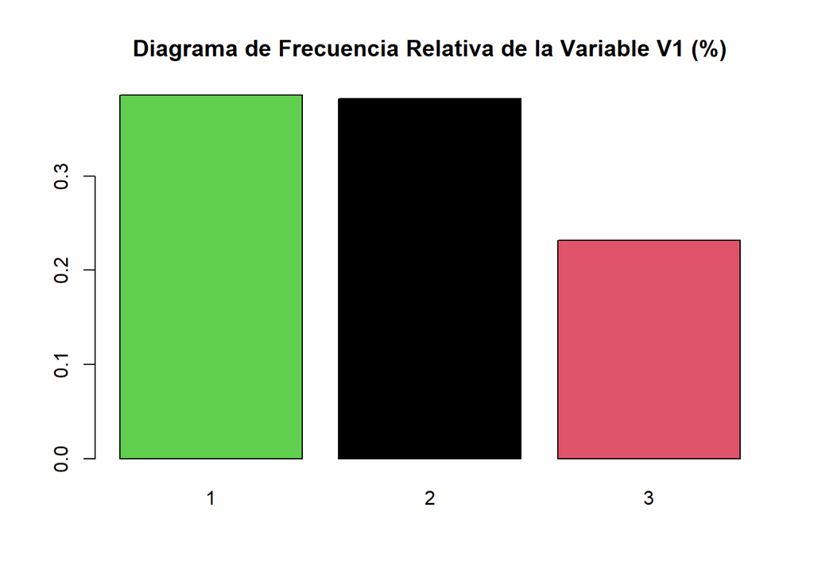

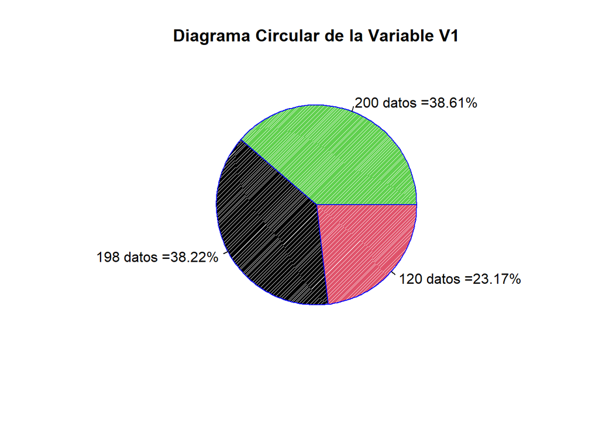

```
## #######################   Variable Juicio_pastel   ########################
## --------------- frecuencia de la variable Juicio_pastel -------------------
##   frecuencia frecuencia_Relativa
## 1          3         0.005791506
## 2         21         0.040540541
## 3         49         0.094594595
## 4         94         0.181467181
## 5        225         0.434362934
## 6         96         0.185328185
## 7         30         0.057915058
## --------------- Entropia de la variable Juicio_pastel -------------------
## [1] Entropia total de la variable Ciudad es:
## [1] 2.210419
## ----------------- Moda de la Variable Juicio_pastel ---------------------
## [1] La moda de Ciudad es:
## [1] 5
## attr(,"freq")
## [1] 225
## ------------- Cuantiles de la Variable Juicio_pastel -------------------
##    1%  2.5%    5%   25%   50%   75%   95% 97.5%   99%
##     2     2     3     4     5     5     7     7     7
```

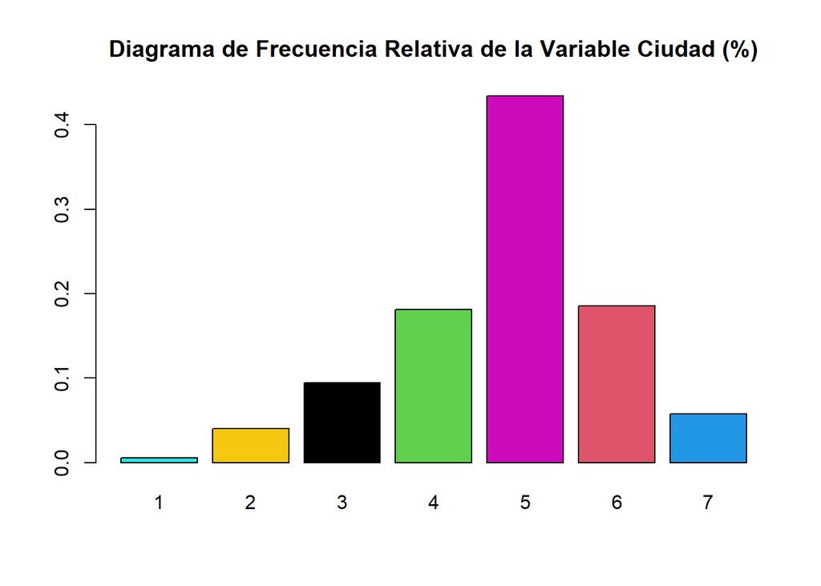

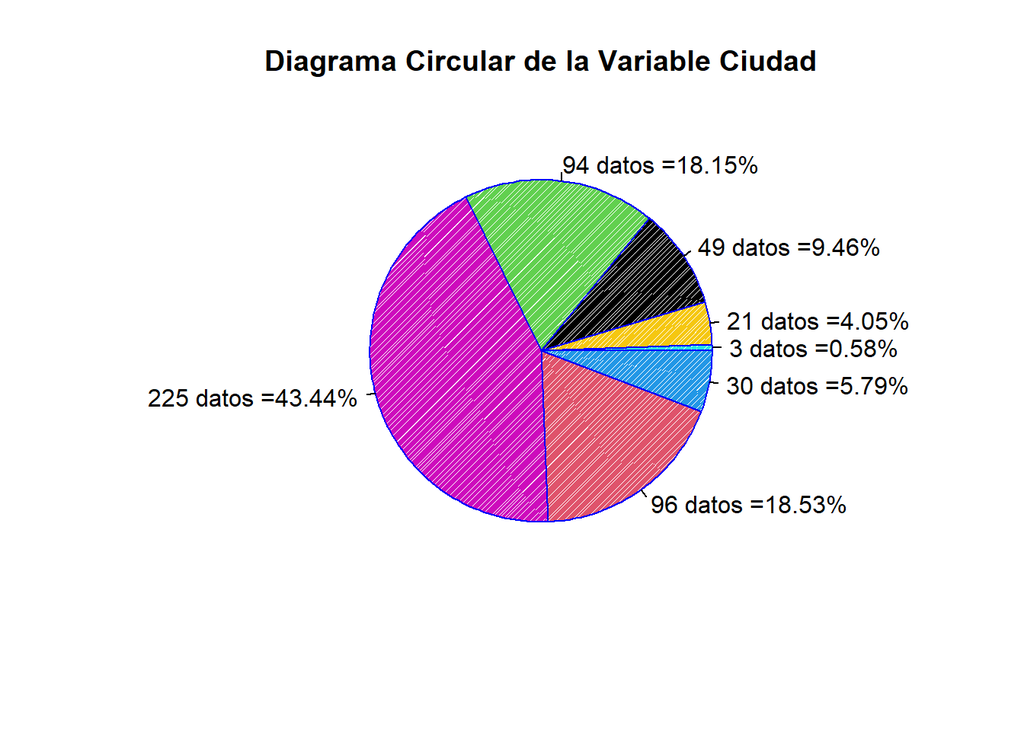

```
## #######################   Variable Compraria   ########################
## --------------- frecuencia de la variable Compraria -------------------
##   frecuencia frecuencia_Relativa
## 1         44          0.08494208
## 2         38          0.07335907
## 3         89          0.17181467
## 4        210          0.40540541
## 5        137          0.26447876
## --------------- Entropia de la variable Compraria -------------------
## [1] Entropia total de la variable Condicion_laboral es:
## [1] 2.050788
## ----------------- Moda de la Variable Compraria ---------------------
## [1] La moda de Condicion_laboral es:
## [1] 4
## attr(,"freq")
## [1] 210
## ------------- Cuantiles de la Variable Compraria -------------------
##    1%  2.5%    5%   25%   50%   75%   95% 97.5%   99%
##     1     1     1     3     4     5     5     5     5
```

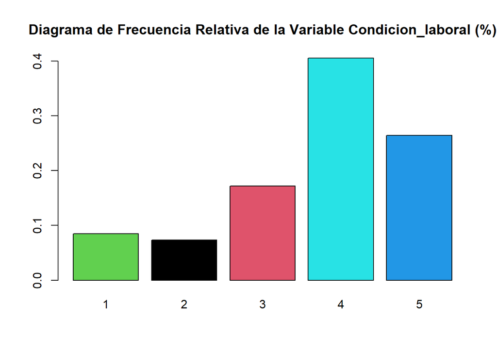

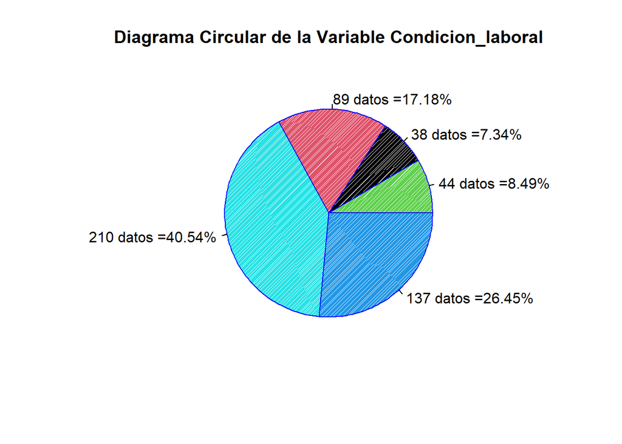

# Pregunta 3

Bajar el archivo Supermercados y calcular el indice de concentración de Lorentz por cada variable.

Se descargara el archivo Supermercados.csv a una carpeta local, luego se cargara el archivo y se muestrara la estructura de la data, luego se muestra los primeros 15 valores de la tabla

```r
# Leer datos desde un archivo CSV
datos_csv <- import("G:/R IMCA/TAREA 4/DESCARGA_DATA/Supermercados.csv")
```

```r
# Verificar la estructura de los datos
str(datos_csv)
```

```
## 'data.frame':    10 obs. of  3 variables:
##  $ Punti_vendita: chr  "Roma" "Parma" "Perugia" "Genova" ...
##  $ Dipendenti_91: int  115 75 5 10 50 100 25 5 10 105
##  $ Dipendenti_92: int  367 60 22 60 38 52 37 38 23 53
```

```r
# Visualizar los primeros registros de los datos
head(datos_csv,n=15)
```

|  | Punti_vendita | Dipendenti_91 | Dipendenti_92 |
| --- | --- | --- | --- |
| 1 | Roma | 115 | 367 |
| 2 | Parma | 75 | 60 |
| 3 | Perugia | 5 | 22 |
| 4 | Genova | 10 | 60 |
| 5 | Torino | 50 | 38 |
| 6 | Firenze | 100 | 52 |
| 7 | Bologna | 25 | 37 |
| 8 | Padova | 5 | 38 |
| 9 | Rovigo | 10 | 23 |
| 10 | Alessandria | 105 | 53 |

Para calcular la curva de Lorenz se tiene primero ordenar los datos de menor a mayor. Luego calculamos la fracción acumulada de los datos y la fracción acumulada de la población. Después, creamos una matriz con las coordenadas de la curva de Lorenz. Calculamos el área bajo la curva de Lorenz y el área bajo la línea de igualdad, y finalmente obtenemos el índice de Gini dividiendo la diferencia entre estas dos áreas por el área bajo la línea de igualdad. Este valor es el índice de concentración de Lorenz o el coeficiente de Gini.

```
## ########  CALCULO DE INDICE CONCENTRACION DE LORENTZ DE LA VARIABLE  Dipendenti_91   ##########
## Datos Ordenados
##  [1]   5   5  10  10  25  50  75 100 105 115
##
## Datos Acumulados
##   [1]   5  10  20  30  55 105 180 280 385 500
##
## Distribucion Acumulada de los datos(qc)
##   [1] 0.00 0.01 0.02 0.04 0.06 0.11 0.21 0.36 0.56 0.77 1.00
##
## Distribucion de pesos(pc)
##  [1] 0.0 0.1 0.2 0.3 0.4 0.5 0.6 0.7 0.8 0.9 1.0
##
## Matriz con coordenadas de la curva de Lorenz
##       fraccion_pesos fraccion_acumulada
##  [1,]            0.0               0.00
##  [2,]            0.1               0.01
##  [3,]            0.2               0.02
##  [4,]            0.3               0.04
##  [5,]            0.4               0.06
##  [6,]            0.5               0.11
##  [7,]            0.6               0.21
##  [8,]            0.7               0.36
##  [9,]            0.8               0.56
## [10,]            0.9               0.77
## [11,]            1.0               1.00
##
## Area bajo la curva Lorenz: 0.264
##
## Area bajo la linea de Igualdad: 0.5
##
## Indice de concentracion Lorenz: 0.472
```

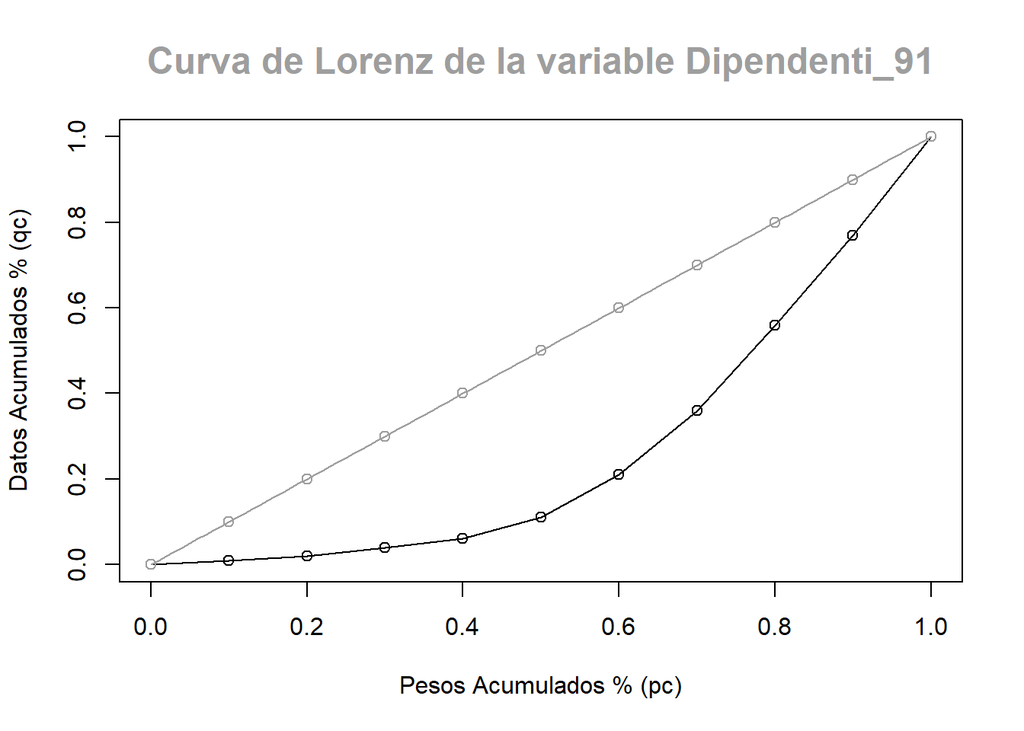

```
## ########  CALCULO DE INDICE CONCENTRACION DE LORENTZ DE LA VARIABLE  Dipendenti_92   ##########
## Datos Ordenados
##  [1]  22  23  37  38  38  52  53  60  60 367
##
## Datos Acumulados
##   [1]  22  45  82 120 158 210 263 323 383 750
##
## Distribucion Acumulada de los datos(qc)
##   [1] 0.00000000 0.02933333 0.06000000 0.10933333 0.16000000 0.21066667
##  [7] 0.28000000 0.35066667 0.43066667 0.51066667 1.00000000
##
## Distribucion de pesos(pc)
##  [1] 0.0 0.1 0.2 0.3 0.4 0.5 0.6 0.7 0.8 0.9 1.0
##
## Matriz con coordenadas de la curva de Lorenz
##       fraccion_pesos fraccion_acumulada
##  [1,]            0.0         0.00000000
##  [2,]            0.1         0.02933333
##  [3,]            0.2         0.06000000
##  [4,]            0.3         0.10933333
##  [5,]            0.4         0.16000000
##  [6,]            0.5         0.21066667
##  [7,]            0.6         0.28000000
##  [8,]            0.7         0.35066667
##  [9,]            0.8         0.43066667
## [10,]            0.9         0.51066667
## [11,]            1.0         1.00000000
##
## Area bajo la curva Lorenz: 0.2641333
##
## Area bajo la linea de Igualdad: 0.5
##
## Indice de concentracion Lorenz: 0.4717333
```

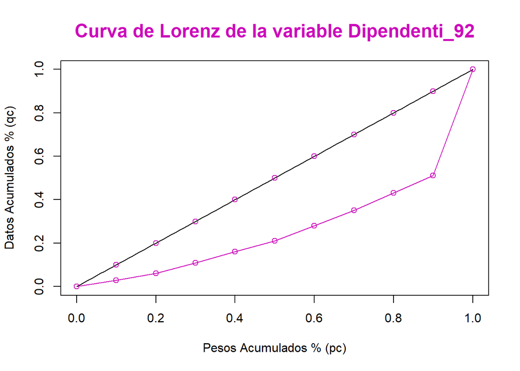

```r
  df<-datos_csv
  columna<-c(2,3)
  nombres<-names(df)
  for(i in 1:length(columna)){
    cat("########  CALCULO DE INDICE CONCENTRACION DE LORENTZ DE LA VARIABLE ",nombres[columna[i]],"  ##########\n")
    datos<-eval(parse(text = paste0("df[,",columna[i],"]")))

    #Ordena los datos de menor a mayor
    datos_ordenados <- sort(datos)
    cat("Datos Ordenados\n")
    print(datos_ordenados)

    # Calcula la fracción acumulada de datos
    cat("\nDatos Acumulados\n ")
    print(cumsum(datos_ordenados))
    fraccion_acumulada <- cumsum(datos_ordenados) / sum(datos_ordenados)
    fraccion_acumulada<-c(0,fraccion_acumulada)

    cat("\nDistribucion Acumulada de los datos(qc)\n ")
    print(fraccion_acumulada)

    # Calcula la fracción acumulada de los pesos
    fraccion_pesos <- seq(0, 1, length.out = length(datos_ordenados)+1)
    cat("\nDistribucion de pesos(pc)\n")
    print(fraccion_pesos)

    # Crea una matriz con las coordenadas de la curva de Lorenz
    cat("\nMatriz con coordenadas de la curva de Lorenz\n")
    lorenz_matriz <- cbind(fraccion_pesos, fraccion_acumulada)
    print(lorenz_matriz)

    # Calcula el área bajo la curva de Lorenz usando el método del trapecio
    area_lorenz<-sum(diff(lorenz_matriz[,1])*(lorenz_matriz[-1,2]+lorenz_matriz[-nrow(lorenz_matriz),2])/2)
    cat("\nArea bajo la curva Lorenz:",area_lorenz,"\n")

    # Calcula el área bajo la línea de igualdad
    cat("\nArea bajo la linea de Igualdad:",area_igualdad <- 0.5,"\n")

    # Calcula el índice de concentración de Lorenz (coeficiente de Gini)
    indice_gini <- (area_igualdad - area_lorenz) / area_igualdad

    # Muestra el resultado
    cat("\nIndice de concentracion Lorenz:",indice_gini,"\n")

    color<-sample(1:8,2,replace=FALSE)
    plot(fraccion_pesos, fraccion_acumulada,
         main= eval(paste0("Curva de Lorenz de la variable ",nombres[columna[i]])),
         cex.main=1.5,
         font.main=2,
         col.main=sample(1:10,1,replace=FALSE),
         xlim=c(0,1),
         xlab = "Pesos Acumulados % (pc)",
         ylab = "Datos Acumulados % (qc)",
         lwd=1,col =color[1] , type = "o")

    curve(x*1,add=TRUE,lwd=1,col=color[2],type="l")
    points(fraccion_pesos,fraccion_pesos, col = sample(1:10,1,replace=FALSE))

  }
```

# Pregunta 4

Bajar el archivo Czechoslovakia.csv desde internet utilizando la dirección http://www.camiz.it/sergio/Universita/Dati/ y cargar-lo en R. Trata-se de 25 clases de personas con diferente nivel de renta.

Se descargara el archivo Czechoslovakia.csv a una carpeta local, luego se cargara el archivo y se muestrara la estructura de la data, luego se muestra los primeros 15 valores de la tabla

```r
# Leer datos desde un archivo CSV
datos_csv <- import("G:/R IMCA/TAREA 4/DESCARGA_DATA/Czechoslovakia.csv")
```

```r
# Verificar la estructura de los datos
str(datos_csv)
```

```
## 'data.frame':    25 obs. of  3 variables:
##  $ Low_range  : int  1 9601 10801 12001 13201 14401 15601 16801 18001 19201 ...
##  $  Persons   : int  176693 237593 472988 640711 800156 1003174 1160966 1257160 1277633 1104486 ...
##  $ Mean_income: int  8421 10290 11545 12638 13845 15036 16277 17420 18610 19814 ...
```

```r
# Visualizar los primeros registros de los datos
head(datos_csv,n=15)
```

|  | Low_range | Persons | Mean_income |
| --- | --- | --- | --- |
| 1 | 1 | 176693 | 8421 |
| 2 | 9601 | 237593 | 10290 |
| 3 | 10801 | 472988 | 11545 |
| 4 | 12001 | 640711 | 12638 |
| 5 | 13201 | 800156 | 13845 |
| 6 | 14401 | 1003174 | 15036 |
| 7 | 15601 | 1160966 | 16277 |
| 8 | 16801 | 1257160 | 17420 |
| 9 | 18001 | 1277633 | 18610 |
| 10 | 19201 | 1104486 | 19814 |

[output cut: 5 more lines]

# Pregunta 5

Calcular el índice de concentración de Lorentz, adaptando el cálculo considerando que en este caso, las unidades de cada grupos de ingresos en la primera columna, con números indicados en la segunda, tienen un ingreso promedio como indicado en la tercera.

```r
    # Carga de la data original
    df<-datos_csv
    columna<-c(1,2,3)
    nombres<-names(df)

    #Manipulando en dataframe para el calculo de la curva
    df[1]<-eval(parse(text = paste0("as.double(df[,",columna[1],"])*","as.double(df[,",columna[2],"])")))
    df[2]<-eval(parse(text = paste0("as.double(df[,",columna[3],"])")))
    colnames(df)<-c(paste0(nombres[1],"*",nombres[2]),nombres[3],nombres[3])
    i=1;

    # CALCULO DE INDICE CONCENTRACION DE LORENTZ
    datos<-eval(parse(text = paste0("df[,",columna[i+1],"]")))

    # Calcula la fracción acumulada de datos
    print("Datos Acumulados",quote = FALSE)
```

```
## [1] Datos Acumulados
```

```r
    print(cumsum(datos))
```

```
##  [1]   8421  18711  30256  42894  56739  71775  88052 105472 124082 143896
## [11] 164904 187107 210513 235116 260926 287924 316141 345560 376176 407980
## [21] 440956 475132 510550 547704 596042
```

```r
    fraccion_acumulada <- cumsum(datos) / sum(datos)
    fraccion_acumulada<-c(0,fraccion_acumulada)
    print("Distribucion Acumulada de los datos(qc) ",quote = FALSE)
```

```
## [1] Distribucion Acumulada de los datos(qc)
```

```r
    print(fraccion_acumulada)
```

```
##  [1] 0.00000000 0.01412820 0.03139208 0.05076152 0.07196473 0.09519296
##  [7] 0.12041937 0.14772784 0.17695397 0.20817661 0.24141923 0.27666507
## [13] 0.31391580 0.35318484 0.39446214 0.43776445 0.48305992 0.53040054
## [19] 0.57975780 0.63112331 0.68448197 0.73980693 0.79714517 0.85656715
## [25] 0.91890169 1.00000000
```

```r
    # Calcula la fracción acumulada de los pesos
    datos2<-eval(parse(text = paste0("df[,",columna[i],"]")))
    print(cumsum(datos2))
```

```
##  [1]       176693   2281307086   7390050474  15079223185  25642082541
##  [6]  40088791315  58201021881  79322567041 102321238674 123528474360
## [11] 143402271718 162230221742 179062353161 195034898656 209638752151
## [16] 222588495453 234585325305 245172371298 254638256817 263386112388
## [21] 271344770018 278291037546 283993216197 293262573672 316498020346
```

```r
    fraccion_pesos <- cumsum(datos2) / sum(datos2)
    fraccion_pesos<-c(0,fraccion_pesos)
    print("Distribucion de pesos(pc)",quote = FALSE)
```

```
## [1] Distribucion de pesos(pc)
```

```r
    print(fraccion_pesos)
```

```
##  [1] 0.000000e+00 5.582752e-07 7.207966e-03 2.334944e-02 4.764397e-02
##  [6] 8.101815e-02 1.266636e-01 1.838906e-01 2.506258e-01 3.232919e-01
## [11] 3.902978e-01 4.530906e-01 5.125789e-01 5.657614e-01 6.162279e-01
## [16] 6.623699e-01 7.032856e-01 7.411905e-01 7.746411e-01 8.045493e-01
## [21] 8.321888e-01 8.573348e-01 8.792821e-01 8.972986e-01 9.265858e-01
## [26] 1.000000e+00
```

```r
    # Crea una matriz con las coordenadas de la curva de Lorenz
    print("Matriz con coordenadas de la curva de Lorenz",quote = FALSE)
```

```
## [1] Matriz con coordenadas de la curva de Lorenz
```

```r
    lorenz_matriz <- cbind(fraccion_pesos, fraccion_acumulada)
    print(lorenz_matriz)
```

```
##       fraccion_pesos fraccion_acumulada
##  [1,]   0.000000e+00         0.00000000
##  [2,]   5.582752e-07         0.01412820
##  [3,]   7.207966e-03         0.03139208
##  [4,]   2.334944e-02         0.05076152
##  [5,]   4.764397e-02         0.07196473
##  [6,]   8.101815e-02         0.09519296
##  [7,]   1.266636e-01         0.12041937
##  [8,]   1.838906e-01         0.14772784
##  [9,]   2.506258e-01         0.17695397
## [10,]   3.232919e-01         0.20817661
## [11,]   3.902978e-01         0.24141923
## [12,]   4.530906e-01         0.27666507
## [13,]   5.125789e-01         0.31391580
## [14,]   5.657614e-01         0.35318484
## [15,]   6.162279e-01         0.39446214
## [16,]   6.623699e-01         0.43776445
## [17,]   7.032856e-01         0.48305992
## [18,]   7.411905e-01         0.53040054
## [19,]   7.746411e-01         0.57975780
## [20,]   8.045493e-01         0.63112331
## [21,]   8.321888e-01         0.68448197
## [22,]   8.573348e-01         0.73980693
## [23,]   8.792821e-01         0.79714517
## [24,]   8.972986e-01         0.85656715
## [25,]   9.265858e-01         0.91890169
## [26,]   1.000000e+00         1.00000000
```

```r
    # Calcula el área bajo la curva de Lorenz usando el método del trapecio
    area_lorenz<-sum(diff(lorenz_matriz[,1])*(lorenz_matriz[-1,2]+lorenz_matriz[-nrow(lorenz_matriz),2])/2)
    print(paste("Area bajo la curva Lorenz:",area_lorenz),quote = FALSE)
```

```
## [1] Area bajo la curva Lorenz: 0.386237100412606
```

```r
    # Calcula el área bajo la línea de igualdad
    area_igualdad <- 0.5
    print(paste("Area bajo la linea de Igualdad:",area_igualdad),quote = FALSE)
```

```
## [1] Area bajo la linea de Igualdad: 0.5
```

```r
    # Calcula el índice de concentración de Lorenz (coeficiente de Gini)
    indice_gini <- (area_igualdad - area_lorenz) / area_igualdad

    # Muestra el resultado
    print(paste("Indice de concentracion Lorenz:",indice_gini),quote = FALSE)
```

```
## [1] Indice de concentracion Lorenz: 0.227525799174788
```

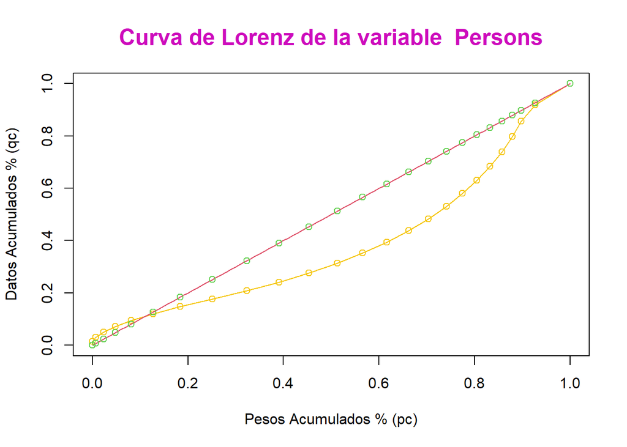

```r
    #Ploteo de resultados
    color<-sample(1:8,2,replace=FALSE)
    plot(fraccion_pesos, fraccion_acumulada,
         main= eval(paste0("Curva de Lorenz de la variable ",nombres[columna[i+1]])),
         cex.main=1.5,
         font.main=2,
         col.main=sample(1:10,1,replace=FALSE),
         xlim=c(0,1),
         xlab = "Pesos Acumulados % (pc)",
         ylab = "Datos Acumulados % (qc)",
         lwd=1,col =color[1] , type = "o")

    curve(x*1,add=TRUE,lwd=1,col=color[2],type="l")
    points(fraccion_pesos,fraccion_pesos, col = sample(1:10,1,replace=FALSE))
```

# Pregunta 6

Bajar el archivo Iris: trata-se de cuatro mediciones sobre 150 flores de Iris de tres especies diferentes. Calcular promedio, varianza, desvío estándar, coeficiente de variación y desvío promedio por todos los caracteres cuantitativos.

Se descargara el archivo Iris.csv a una carpeta local, luego se cargara el archivo y se muestrara la estructura de la data, luego se muestra los primeros 15 valores de la tabla

```r
# Leer datos desde un archivo CSV
datos_csv <- import("G:/R IMCA/TAREA 4/DESCARGA_DATA/Iris.csv")
# Verificar la estructura de los datos
str(datos_csv)
```

```
## 'data.frame':    150 obs. of  6 variables:
##  $ V1          : int  1 2 3 4 5 6 7 8 9 10 ...
##  $ Sepal length: num  5.1 4.9 4.7 4.6 5 5.4 4.6 5 4.4 4.9 ...
##  $ Sepal width : num  3.5 3 3.2 3.1 3.6 3.9 3.4 3.4 2.9 3.1 ...
##  $ Petal length: num  1.4 1.4 1.3 1.5 1.4 1.7 1.4 1.5 1.4 1.5 ...
##  $ Petal width : num  0.2 0.2 0.2 0.2 0.2 0.4 0.3 0.2 0.2 0.1 ...
##  $ Species     : chr  "setosa" "setosa" "setosa" "setosa" ...
```

```r
# Visualizar los primeros registros de los datos
head(datos_csv,n=15)
```

|  | V1 | Sepal length | Sepal width | Petal length | Petal width | Species |
| --- | --- | --- | --- | --- | --- | --- |
| 1 | 1 | 5.1 | 3.5 | 1.4 | 0.2 | setosa |
| 2 | 2 | 4.9 | 3.0 | 1.4 | 0.2 | setosa |
| 3 | 3 | 4.7 | 3.2 | 1.3 | 0.2 | setosa |
| 4 | 4 | 4.6 | 3.1 | 1.5 | 0.2 | setosa |
| 5 | 5 | 5.0 | 3.6 | 1.4 | 0.2 | setosa |
| 6 | 6 | 5.4 | 3.9 | 1.7 | 0.4 | setosa |
| 7 | 7 | 4.6 | 3.4 | 1.4 | 0.3 | setosa |
| 8 | 8 | 5.0 | 3.4 | 1.5 | 0.2 | setosa |
| 9 | 9 | 4.4 | 2.9 | 1.4 | 0.2 | setosa |
| 10 | 10 | 4.9 | 3.1 | 1.5 | 0.1 | setosa |

[output cut: 5 more lines]

Observamos de las 6 variables, 5 son variables numericas y una es variable categorica. Se paras ha hacer las estadisticas correspondiente a la variable numericas.

```r
#Caculo de las estadisticas de las 6 variables
#Estad(datos_csv,c(1,2,3,4,5))
```

```r
  df<-datos_csv
  columna<-c(1,2,3,4,5)
  nombres<-names(df)


  for(i in 1:length(columna)){
    cat("\n\n###################  ESTADISTICA DE LA VARIABLE",nombres[columna[i]],"  #######################\n")
    datos<-eval(parse(text = paste0("df[,",columna[i],"]")))

    # Calcular el media de la columna i
    cat("\n------------------ Promedio de la Variable",nombres[columna[i]],"-------------------\n")
    promedio_columna <- mean(datos)
    cat("Promedio: ",promedio_columna)

    # Calculo de la varianza de los datos
    cat("\n------------------ Varianza de la Variable",nombres[columna[i]],"-------------------\n")
    varianza <- var(datos)
    cat("Varianza: ",varianza)

    # Calcular la desviación estándar de los datos
    cat("\n-------------- Desviacion Standar de la Variable",nombres[columna[i]],"-------------------\n")
    desviacion_estandar <- sd(datos)
    cat("Desv Standar: ",desviacion_estandar)

    # Calcular la desviación promedio
    cat("\n-------------- Desviacion promedio de la Variable",nombres[columna[i]],"-------------------\n")
    # Calcular las diferencias absolutas entre los datos y la media
    diferencias_absolutas <- abs(datos - promedio_columna)
    desvio_promedio <- mean(diferencias_absolutas)
    cat("Desviacion promedio: ",desvio_promedio)

    # Impresion de coeficiente de variacion
    cat("\n------------- Coeficiente de Variacion de la Variable",nombres[columna[i]],"-------------------\n")
    sigma<-eval(parse(text = paste0("sd(df[,",columna[i],"])")))
    mu<-eval(parse(text = paste0("mean(df[,",columna[i],"])")))
    cv <- sigma / abs(mu)
    cat("Coef Variacion: ",cv)
    }
```

```
##
##
## ###################  ESTADISTICA DE LA VARIABLE V1   #######################
##
## ------------------ Promedio de la Variable V1 -------------------
## Promedio:  75.5
## ------------------ Varianza de la Variable V1 -------------------
## Varianza:  1887.5
## -------------- Desviacion Standar de la Variable V1 -------------------
## Desv Standar:  43.44537
## -------------- Desviacion promedio de la Variable V1 -------------------
## Desviacion promedio:  37.5
## ------------- Coeficiente de Variacion de la Variable V1 -------------------
## Coef Variacion:  0.5754353
##
## ###################  ESTADISTICA DE LA VARIABLE Sepal length   #######################
##
## ------------------ Promedio de la Variable Sepal length -------------------
## Promedio:  5.843333
## ------------------ Varianza de la Variable Sepal length -------------------
## Varianza:  0.6856935
## -------------- Desviacion Standar de la Variable Sepal length -------------------
## Desv Standar:  0.8280661
## -------------- Desviacion promedio de la Variable Sepal length -------------------
## Desviacion promedio:  0.6875556
## ------------- Coeficiente de Variacion de la Variable Sepal length -------------------
## Coef Variacion:  0.1417113
##
## ###################  ESTADISTICA DE LA VARIABLE Sepal width   #######################
##
## ------------------ Promedio de la Variable Sepal width -------------------
## Promedio:  3.057333
## ------------------ Varianza de la Variable Sepal width -------------------
## Varianza:  0.1899794
## -------------- Desviacion Standar de la Variable Sepal width -------------------
## Desv Standar:  0.4358663
## -------------- Desviacion promedio de la Variable Sepal width -------------------
## Desviacion promedio:  0.3367822
## ------------- Coeficiente de Variacion de la Variable Sepal width -------------------
## Coef Variacion:  0.1425642
```

[output cut: 11 more lines]

```
## ------------- Coeficiente de Variacion de la Variable Petal length -------------------
## Coef Variacion:  0.4697441
##
## ###################  ESTADISTICA DE LA VARIABLE Petal width   #######################
##
## ------------------ Promedio de la Variable Petal width -------------------
## Promedio:  1.199333
## ------------------ Varianza de la Variable Petal width -------------------
## Varianza:  0.5810063
## -------------- Desviacion Standar de la Variable Petal width -------------------
## Desv Standar:  0.7622377
## -------------- Desviacion promedio de la Variable Petal width -------------------
## Desviacion promedio:  0.6581333
## ------------- Coeficiente de Variacion de la Variable Petal width -------------------
## Coef Variacion:  0.6355511
```

# Pregunta 7

Intentar de construir una función que calcule todas las estadísticas y aplicarla en seguida.

A continuacion definimos le funcion que nos ayudara calcular el promedio, varianza, desvío estándar, coeficiente de variación y desvío promedio por todos los caracteres. La funcion recivira como parametros una dataframe y un vector de las variables que se esta requiriendo la estadistica.

```r
Estad<-function(df,columna){
  nombres<-names(df)
  for(i in 1:length(columna)){
    cat("\n\n###################  ESTADISTICA DE LA VARIABLE",nombres[columna[i]],"  #######################\n")
    datos<-eval(parse(text = paste0("df[,",columna[i],"]")))

    # Calcular el media de la columna i
    cat("\n------------------ Promedio de la Variable",nombres[columna[i]],"-------------------\n")
    promedio_columna <- mean(datos)
    cat("Promedio: ",promedio_columna)

    # Calculo de la varianza de los datos
    cat("\n------------------ Varianza de la Variable",nombres[columna[i]],"-------------------\n")
    varianza <- var(datos)
    cat("Varianza: ",varianza)

    # Calcular la desviación estándar de los datos
    cat("\n-------------- Desviacion Standar de la Variable",nombres[columna[i]],"-------------------\n")
    desviacion_estandar <- sd(datos)
    cat("Desv Standar: ",desviacion_estandar)

    # Calcular la desviación promedio
    cat("\n-------------- Desviacion promedio de la Variable",nombres[columna[i]],"-------------------\n")
    # Calcular las diferencias absolutas entre los datos y la media
    diferencias_absolutas <- abs(datos - promedio_columna)
    desvio_promedio <- mean(diferencias_absolutas)
    cat("Desviacion promedio: ",desvio_promedio)

    # Impresion de coeficiente de variacion
    cat("\n------------- Coeficiente de Variacion de la Variable",nombres[columna[i]],"-------------------\n")
    sigma<-eval(parse(text = paste0("sd(df[,",columna[i],"])")))
    mu<-eval(parse(text = paste0("mean(df[,",columna[i],"])")))
    cv <- sigma / abs(mu)
    cat("Coef Variacion: ",cv)
    }
}
```

```r
#Caculo de las estadisticas de las 6 variables
Estad(datos_csv,c(1,2,3,4,5))
```

```
##
##
## ###################  ESTADISTICA DE LA VARIABLE V1   #######################
##
## ------------------ Promedio de la Variable V1 -------------------
## Promedio:  75.5
## ------------------ Varianza de la Variable V1 -------------------
## Varianza:  1887.5
## -------------- Desviacion Standar de la Variable V1 -------------------
## Desv Standar:  43.44537
## -------------- Desviacion promedio de la Variable V1 -------------------
## Desviacion promedio:  37.5
## ------------- Coeficiente de Variacion de la Variable V1 -------------------
## Coef Variacion:  0.5754353
##
## ###################  ESTADISTICA DE LA VARIABLE Sepal length   #######################
##
## ------------------ Promedio de la Variable Sepal length -------------------
## Promedio:  5.843333
## ------------------ Varianza de la Variable Sepal length -------------------
## Varianza:  0.6856935
## -------------- Desviacion Standar de la Variable Sepal length -------------------
## Desv Standar:  0.8280661
## -------------- Desviacion promedio de la Variable Sepal length -------------------
## Desviacion promedio:  0.6875556
## ------------- Coeficiente de Variacion de la Variable Sepal length -------------------
## Coef Variacion:  0.1417113
##
## ###################  ESTADISTICA DE LA VARIABLE Sepal width   #######################
##
## ------------------ Promedio de la Variable Sepal width -------------------
## Promedio:  3.057333
## ------------------ Varianza de la Variable Sepal width -------------------
## Varianza:  0.1899794
## -------------- Desviacion Standar de la Variable Sepal width -------------------
## Desv Standar:  0.4358663
## -------------- Desviacion promedio de la Variable Sepal width -------------------
## Desviacion promedio:  0.3367822
## ------------- Coeficiente de Variacion de la Variable Sepal width -------------------
## Coef Variacion:  0.1425642
```

[output cut: 11 more lines]

```
## ------------- Coeficiente de Variacion de la Variable Petal length -------------------
## Coef Variacion:  0.4697441
##
## ###################  ESTADISTICA DE LA VARIABLE Petal width   #######################
##
## ------------------ Promedio de la Variable Petal width -------------------
## Promedio:  1.199333
## ------------------ Varianza de la Variable Petal width -------------------
## Varianza:  0.5810063
## -------------- Desviacion Standar de la Variable Petal width -------------------
## Desv Standar:  0.7622377
## -------------- Desviacion promedio de la Variable Petal width -------------------
## Desviacion promedio:  0.6581333
## ------------- Coeficiente de Variacion de la Variable Petal width -------------------
## Coef Variacion:  0.6355511
```

# Pregunta 8

Bajar el archivo Linnerud en un cualquier formado. Trata-se de 20 atletas de un gimnasio con tres mediciones físicas: Peso, Cintura y Pulsaciones, y tres resultados de ejercicios: Tracciones, Flexiones y Saltos.

Se descargara el archivo Linnerud.csv a una carpeta local, luego se cargara el archivo y se muestrara la estructura de la data, luego se muestra los primeros 15 valores de la tabla.

```r
# Leer datos desde un archivo CSV
datos_csv <- import("G:/R IMCA/TAREA 4/DESCARGA_DATA/Linnerud.csv")
```

```r
# Verificar la estructura de los datos
str(datos_csv)
```

```
## 'data.frame':    20 obs. of  7 variables:
##  $ V1          : int  1 2 3 4 5 6 7 8 9 10 ...
##  $ Peso        : int  191 189 193 162 189 182 211 167 176 154 ...
##  $ Cintura     : int  36 37 38 35 35 36 38 34 31 33 ...
##  $ Pulsaciones : int  50 52 58 62 46 56 56 60 74 56 ...
##  $ Lanzamientos: int  5 2 12 12 13 4 8 6 15 17 ...
##  $ Flexiones   : int  162 110 101 105 155 101 101 125 200 251 ...
##  $ Saltos      : int  60 60 101 37 58 42 38 40 40 250 ...
```

```r
# Visualizar los primeros registros de los datos
head(datos_csv,n=15)
```

|  | V1 | Peso | Cintura | Pulsaciones | Lanzamientos | Flexiones | Saltos |
| --- | --- | --- | --- | --- | --- | --- | --- |
| 1 | 1 | 191 | 36 | 50 | 5 | 162 | 60 |
| 2 | 2 | 189 | 37 | 52 | 2 | 110 | 60 |
| 3 | 3 | 193 | 38 | 58 | 12 | 101 | 101 |
| 4 | 4 | 162 | 35 | 62 | 12 | 105 | 37 |
| 5 | 5 | 189 | 35 | 46 | 13 | 155 | 58 |
| 6 | 6 | 182 | 36 | 56 | 4 | 101 | 42 |
| 7 | 7 | 211 | 38 | 56 | 8 | 101 | 38 |
| 8 | 8 | 167 | 34 | 60 | 6 | 125 | 40 |
| 9 | 9 | 176 | 31 | 74 | 15 | 200 | 40 |
| 10 | 10 | 154 | 33 | 56 | 17 | 251 | 250 |

[output cut: 5 more lines]

Observamos que las 7 variables son numericas, las cuales ser hara la estadistica correspondiente.

# Pregunta 9

Calcular promedio, varianza, desvío estándar, coeficiente de variación y desvío promedio por todos los caracteres.

A continuacion definimos le funcion que nos ayudara calcular el promedio, varianza, desvío estándar, coeficiente de variación y desvío promedio por todos los caracteres. La funcion recivira como parametros una dataframe y un vector de las variables que se esta requiriendo la estadistica.

```r
Estad<-function(df,columna){
  nombres<-names(df)
  for(i in 1:length(columna)){
    cat("\n\n\n###################  ESTADISTICA DE LA VARIABLE",nombres[columna[i]],"  #######################\n")
    datos<-eval(parse(text = paste0("df[,",columna[i],"]")))

    # Calcular el media de la columna i
    cat("\n------------------ Promedio de la Variable",nombres[columna[i]],"-------------------\n")
    promedio_columna <- mean(datos)
    cat("Promedio: ",promedio_columna)

    # Calculo de la varianza de los datos
    cat("\n\n------------------ Varianza de la Variable",nombres[columna[i]],"-------------------\n")
    varianza <- var(datos)
    cat("Varianza: ",varianza)

    # Calcular la desviación estándar de los datos
    cat("\n\n-------------- Desviacion Standar de la Variable",nombres[columna[i]],"-------------------\n")
    desviacion_estandar <- sd(datos)
    cat("Desv Standar: ",desviacion_estandar)

    # Calcular la desviación promedio
    cat("\n\n-------------- Desviacion promedio de la Variable",nombres[columna[i]],"-------------------\n")
    # Calcular las diferencias absolutas entre los datos y la media
    diferencias_absolutas <- abs(datos - promedio_columna)
    desvio_promedio <- mean(diferencias_absolutas)
    cat("Desviacion promedio: ",desvio_promedio)

    # Impresion de coeficiente de variacion
    cat("\n\n------------- Coeficiente de Variacion de la Variable",nombres[columna[i]],"-------------------\n")
    sigma<-eval(parse(text = paste0("sd(df[,",columna[i],"])")))
    mu<-eval(parse(text = paste0("mean(df[,",columna[i],"])")))
    cv <- sigma / abs(mu)
    cat("Coef Variacion: ",cv)
    }
}
```

Pasamos a Calular las estadisticas para las 7 variables.

```r
#Caculo de las estadisticas de las 7 variables
Estad(datos_csv,c(1:7))
```

```
##
##
##
## ###################  ESTADISTICA DE LA VARIABLE V1   #######################
##
## ------------------ Promedio de la Variable V1 -------------------
## Promedio:  10.5
##
## ------------------ Varianza de la Variable V1 -------------------
## Varianza:  35
##
## -------------- Desviacion Standar de la Variable V1 -------------------
## Desv Standar:  5.91608
##
## -------------- Desviacion promedio de la Variable V1 -------------------
## Desviacion promedio:  5
##
## ------------- Coeficiente de Variacion de la Variable V1 -------------------
## Coef Variacion:  0.5634362
##
##
## ###################  ESTADISTICA DE LA VARIABLE Peso   #######################
##
## ------------------ Promedio de la Variable Peso -------------------
## Promedio:  178.6
##
## ------------------ Varianza de la Variable Peso -------------------
## Varianza:  609.6211
##
## -------------- Desviacion Standar de la Variable Peso -------------------
## Desv Standar:  24.69051
##
## -------------- Desviacion promedio de la Variable Peso -------------------
## Desviacion promedio:  18.96
##
## ------------- Coeficiente de Variacion de la Variable Peso -------------------
## Coef Variacion:  0.1382447
##
##
## ###################  ESTADISTICA DE LA VARIABLE Cintura   #######################
```

[output cut: 72 more lines]

```
##
## ------------------ Promedio de la Variable Saltos -------------------
## Promedio:  70.3
##
## ------------------ Varianza de la Variable Saltos -------------------
## Varianza:  2629.379
##
## -------------- Desviacion Standar de la Variable Saltos -------------------
## Desv Standar:  51.27747
##
## -------------- Desviacion promedio de la Variable Saltos -------------------
## Desviacion promedio:  35.19
##
## ------------- Coeficiente de Variacion de la Variable Saltos -------------------
## Coef Variacion:  0.7294092
```